# **Modele nieliniowe**

#### **Semestr letni 2022/23**

## **Modele nieliniowe**

Używamy zbioru danych `Wage` z pakietu `ISLR`.

```r
library(ISLR)
```

### **Regresja wielomianowa**

Regresja wielomianowa stopnia 4 `wage` względem `age`.

```r
fit_poly <- lm(wage ~ poly(age, 4), data = Wage)
summary(fit_poly)
```

```
##
## Call:
## lm(formula = wage ~ poly(age, 4), data = Wage)
##
## Residuals:
##     Min      1Q  Median      3Q     Max
## -98.707 -24.626  -4.993  15.217 203.693
##
## Coefficients:
##                Estimate Std. Error t value Pr(>|t|)
## (Intercept)    111.7036     0.7287 153.283  < 2e-16 ***
## poly(age, 4)1  447.0679    39.9148  11.201  < 2e-16 ***
## poly(age, 4)2 -478.3158    39.9148 -11.983  < 2e-16 ***
## poly(age, 4)3  125.5217    39.9148   3.145  0.00168 **
## poly(age, 4)4  -77.9112    39.9148  -1.952  0.05104 .
## ---
## Signif. codes:  0 '***' 0.001 '**' 0.01 '*' 0.05 '.' 0.1 ' ' 1
##
## Residual standard error: 39.91 on 2995 degrees of freedom
## Multiple R-squared:  0.08626,    Adjusted R-squared:  0.08504
## F-statistic: 70.69 on 4 and 2995 DF,  p-value: < 2.2e-16
```

To samo z użyciem standardowej bazy wielomianów $X, X^{2}, X^{3}, X^{4}$.

```r
fit_poly_raw <- lm(wage ~ poly(age, 4, raw = TRUE), data = Wage)
summary(fit_poly_raw)
```

```
##
## Call:
## lm(formula = wage ~ poly(age, 4, raw = TRUE), data = Wage)
##
## Residuals:
##     Min      1Q  Median      3Q     Max
## -98.707 -24.626  -4.993  15.217 203.693
##
## Coefficients:
##                             Estimate Std. Error t value Pr(>|t|)
## (Intercept)               -1.842e+02  6.004e+01  -3.067 0.002180 **
## poly(age, 4, raw = TRUE)1  2.125e+01  5.887e+00   3.609 0.000312 ***
## poly(age, 4, raw = TRUE)2 -5.639e-01  2.061e-01  -2.736 0.006261 **
## poly(age, 4, raw = TRUE)3  6.811e-03  3.066e-03   2.221 0.026398 *
## poly(age, 4, raw = TRUE)4 -3.204e-05  1.641e-05  -1.952 0.051039 .
## ---
## Signif. codes:  0 '***' 0.001 '**' 0.01 '*' 0.05 '.' 0.1 ' ' 1
##
## Residual standard error: 39.91 on 2995 degrees of freedom
## Multiple R-squared:  0.08626,    Adjusted R-squared:  0.08504
## F-statistic: 70.69 on 4 and 2995 DF,  p-value: < 2.2e-16
```

To samo, co powyżej, inaczej zapisane

```r
fit_poly_raw <- lm(wage ~ age + I(age^2) + I(age^3) + I(age^4), data = Wage)
summary(fit_poly_raw)
```

```
##
## Call:
## lm(formula = wage ~ age + I(age^2) + I(age^3) + I(age^4), data = Wage)
##
## Residuals:
##     Min      1Q  Median      3Q     Max
## -98.707 -24.626  -4.993  15.217 203.693
##
## Coefficients:
##               Estimate Std. Error t value Pr(>|t|)
## (Intercept) -1.842e+02  6.004e+01  -3.067 0.002180 **
## age          2.125e+01  5.887e+00   3.609 0.000312 ***
## I(age^2)    -5.639e-01  2.061e-01  -2.736 0.006261 **
## I(age^3)     6.811e-03  3.066e-03   2.221 0.026398 *
## I(age^4)    -3.204e-05  1.641e-05  -1.952 0.051039 .
## ---
## Signif. codes:  0 '***' 0.001 '**' 0.01 '*' 0.05 '.' 0.1 ' ' 1
##
## Residual standard error: 39.91 on 2995 degrees of freedom
## Multiple R-squared:  0.08626,    Adjusted R-squared:  0.08504
## F-statistic: 70.69 on 4 and 2995 DF,  p-value: < 2.2e-16
```

Obrazek dopasowania zawierający krzywe błędu standardowego.

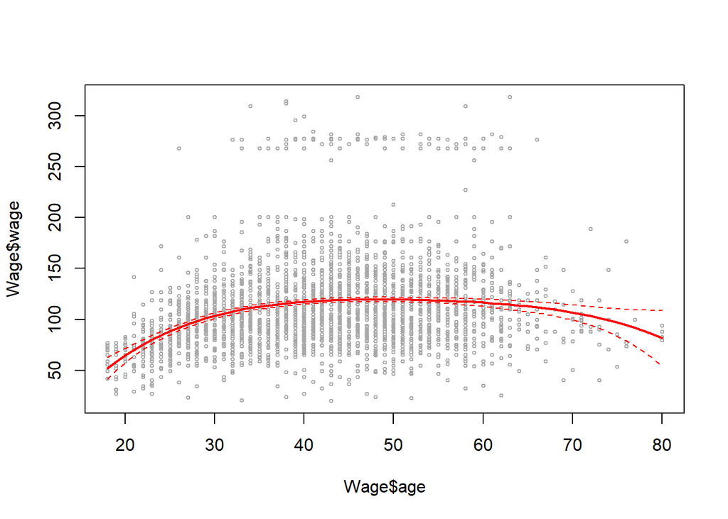

```r
age_lims <- range(Wage$age)
age_grid <- seq(age_lims[1], age_lims[2])
pred_poly <- predict(fit_poly, list(age = age_grid), se.fit = TRUE)
se_bands <- cbind(pred_poly$fit + 2 * pred_poly$se.fit,
                  pred_poly$fit - 2 * pred_poly$se.fit)
plot(Wage$age, Wage$wage, col = "darkgrey", cex = 0.5, xlim = age_lims)
lines(age_grid, pred_poly$fit, col = "red", lwd = 2)
matlines(age_grid, se_bands, col = "red", lty = "dashed")
```

### **Regresja logistyczna wielomianowa**

Chcemy skonstruować klasyfikator z dwoma klasami: dużo zarabiających (więcej niż 250 000 dolarów: warunek `wage > 250`) i mało zarabiających (pozostali). Predyktorem jest `age`, ale chcemy też uwzględnić wpływ wyższych potęg (do 4) tej zmiennej.

```r
fit_log_poly <- glm(I(wage > 250) ~ poly(age, 4), data = Wage, family = binomial)
```

Funkcja `predict.glm()` standardowo zwraca szanse logarytmiczne, co jest korzystne z punktu widzenia zobrazowania błędu standardowego. Musimy jednak otrzymane wartości przekształcić funkcją logistyczną.

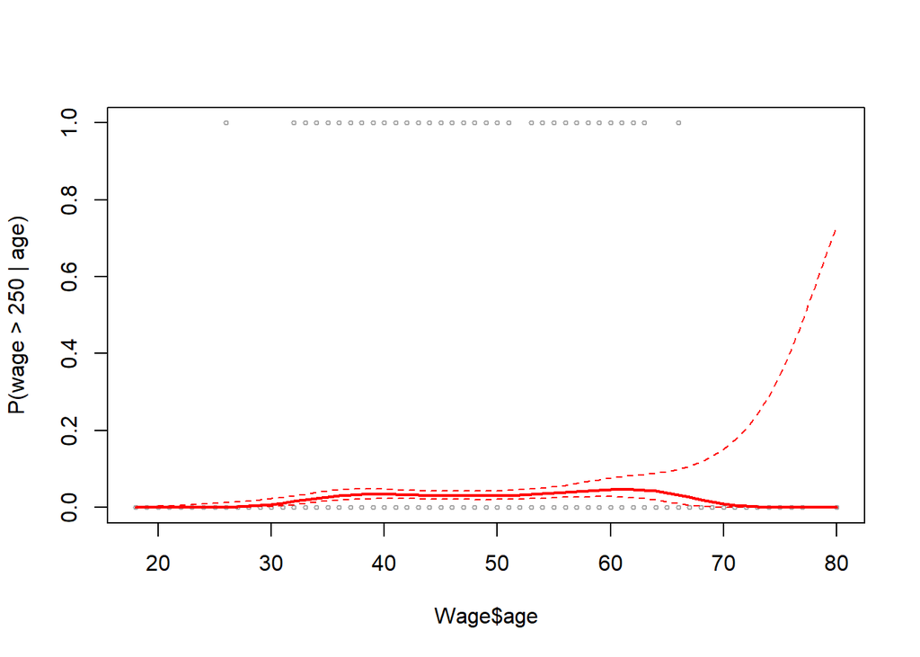

```r
pred_log_poly <- predict(fit_log_poly, list(age = age_grid), se.fit = TRUE)
pred_probs <- plogis(pred_log_poly$fit)
se_bands_logit <- cbind(pred_log_poly$fit + 2 * pred_log_poly$se.fit,
                        pred_log_poly$fit - 2 * pred_log_poly$se.fit)
se_bands <- plogis(se_bands_logit)
plot(Wage$age, I(Wage$wage > 250), xlim = age_lims, ylim = c(0, 1),
     col = "darkgrey", cex = 0.5, ylab = "P(wage > 250 | age)")
lines(age_grid, pred_probs, col = "red", lwd = 2)
matlines(age_grid, se_bands, lty = "dashed", col = "red")
```

"Powiększenie" rysunku można uzyskać np. ograniczając zakres `y` (parametr `ylim`).

### **Funkcje schodkowe**

Dopasowanie funkcji schodkowej wykonujemy przy pomocy funkcji `cut()` przekształcającej zmienną numeryczną w czynnik uporządkowany.

```r
table(cut(Wage$age, breaks = 4))
```

```
##
## (17.9,33.5]   (33.5,49]   (49,64.5] (64.5,80.1]
##         750        1399         779          72
```

Samo dopasowanie wykonuje funkcja `lm()`.

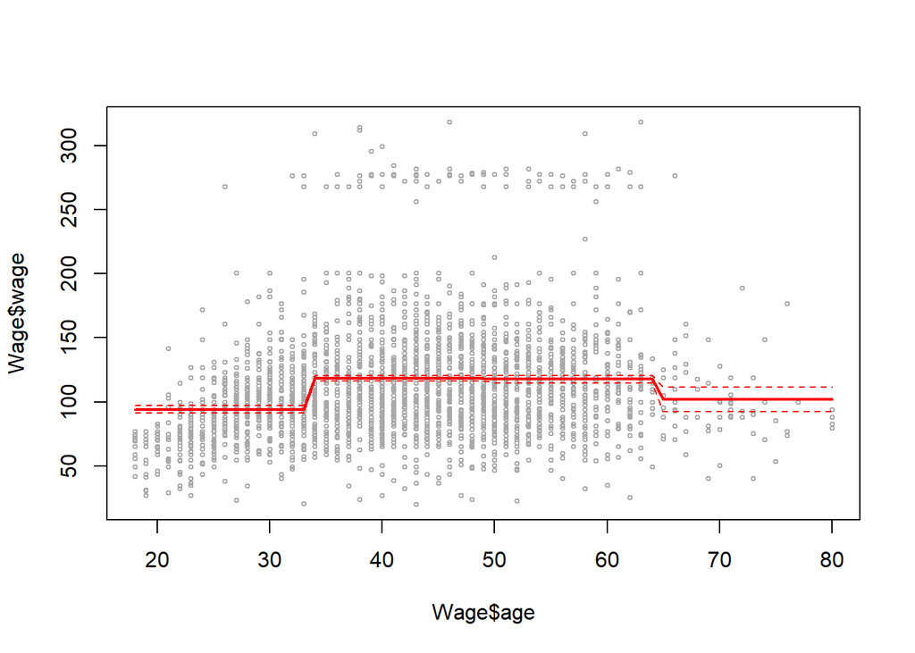

```r
fit_step <- lm(wage ~ cut(age, 4), data = Wage)
pred_step <- predict(fit_step, list(age = age_grid), se.fit = TRUE)
se_bands <- cbind(pred_step$fit + 2 * pred_step$se.fit,
                  pred_step$fit - 2 * pred_step$se.fit)
plot(Wage$age, Wage$wage, col = "darkgrey", cex = 0.5, xlim = age_lims)
lines(age_grid, pred_step$fit, col = "red", lwd = 2)
matlines(age_grid, se_bands, col = "red", lty = "dashed")
```

### **Funkcje sklejane**

Bazę regresyjnych funkcji sklejanych wylicza funkcja `bs()` z pakietu `splines`. Domyślnym stopniem funkcji sklejanych jest 3.

```r
library(splines)
```

Regresja z użyciem funkcji sklejanych z ustalonymi węzłami.

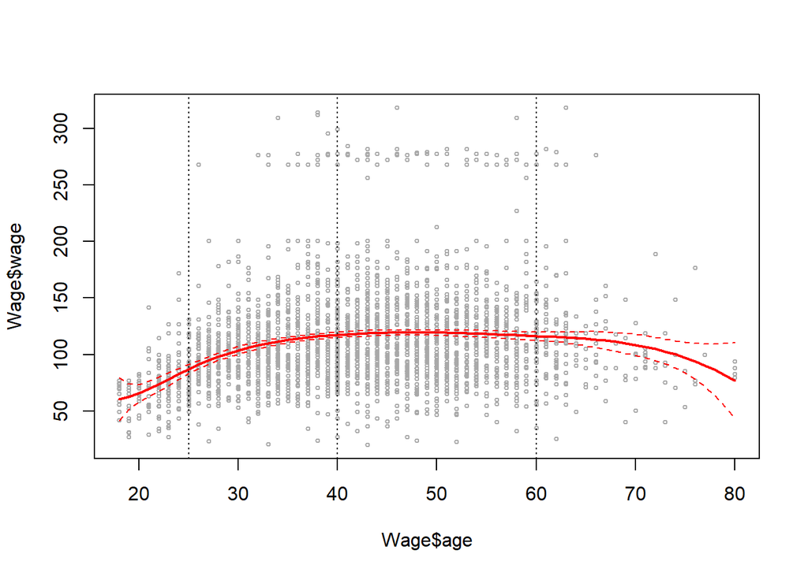

```r
fit_bs_knots <- lm(wage ~ bs(age, knots = c(25, 40, 60)), data = Wage)
pred_bs_knots <- predict(fit_bs_knots, list(age = age_grid), se.fit = TRUE)
plot(Wage$age, Wage$wage, cex = 0.5, col = "darkgrey")
lines(age_grid, pred_bs_knots$fit, col = "red", lwd = 2)
lines(age_grid, pred_bs_knots$fit + 2 * pred_bs_knots$se.fit, col = "red",
      lty = "dashed")
lines(age_grid, pred_bs_knots$fit - 2 * pred_bs_knots$se.fit, col = "red",
      lty = "dashed")
abline(v = c(25, 40, 60), lty = "dotted")
```

Dopasowanie modelu wykorzystującego funkcje sklejane o ustalonej liczbie stopni swobody. Węzły są rozmieszczane automatycznie.

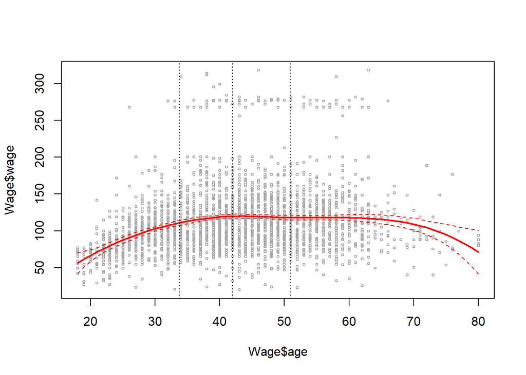

```r
fit_bs_df <- lm(wage ~ bs(age, df = 6), data = Wage)
pred_bs_df <- predict(fit_bs_df, list(age = age_grid), se.fit = TRUE)
plot(Wage$age, Wage$wage, cex = 0.5, col = "darkgrey")
lines(age_grid, pred_bs_df$fit, col = "red", lwd = 2)
lines(age_grid, pred_bs_df$fit + 2 * pred_bs_df$se.fit, col = "red",
      lty = "dashed")
lines(age_grid, pred_bs_df$fit - 2 * pred_bs_df$se.fit, col = "red",
      lty = "dashed")
bs_knots <- attr(bs(Wage$age, df = 6), "knots")
abline(v = bs_knots, lty = "dotted")
```

### **Naturalne funkcje sklejane**

Bazę naturalnych *sześciennych* funkcji sklejanych wyznacza funkcja `ns()` z pakietu `splines`.

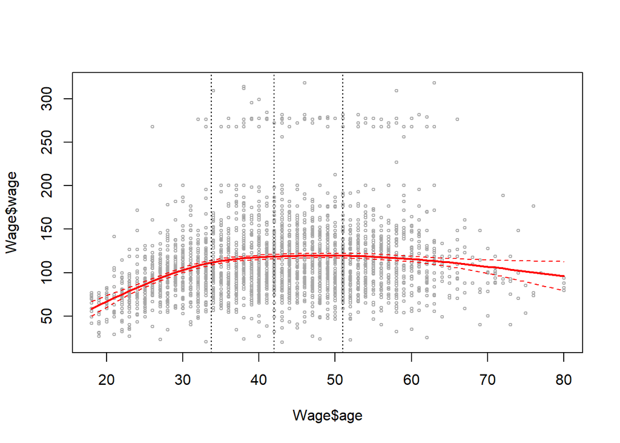

```r
fit_ns <- lm(wage ~ ns(age, df = 4), data = Wage)
pred_ns <- predict(fit_ns, list(age = age_grid), se.fit = TRUE)
plot(Wage$age, Wage$wage, cex = 0.5, col = "darkgrey")
lines(age_grid, pred_ns$fit, col = "red", lwd = 2)
lines(age_grid, pred_ns$fit + 2 * pred_ns$se.fit, col = "red",
      lty = "dashed")
lines(age_grid, pred_ns$fit - 2 * pred_ns$se.fit, col = "red",
      lty = "dashed")
abline(v = attr(ns(Wage$age, df = 4), "knots"), lty = "dotted")
```

### **Wygładzające funkcje sklejane**

Dopasowanie wygładzającej (sześciennej) funkcji sklejanej do danych wykonuje funkcja `smooth.spline()`. Możemy dopasować wygładzającą funkcję sklejaną o ustalonej liczbie stopni swobody (tu 16).

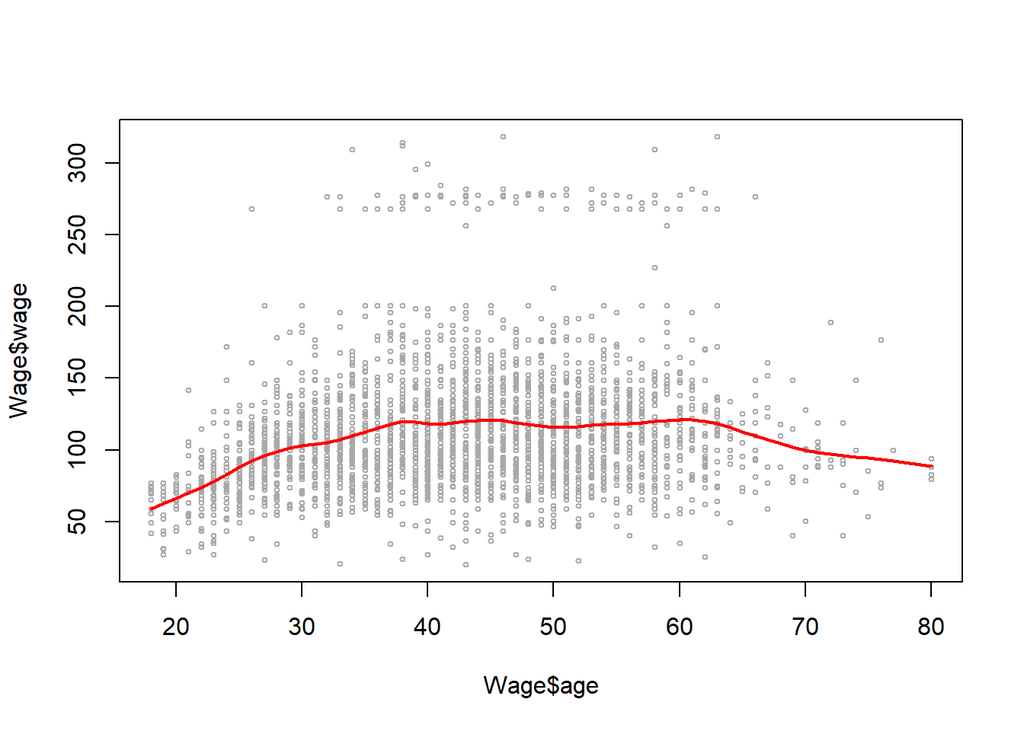

```r
fit_smooth_df <- smooth.spline(Wage$age, Wage$wage, df = 16)
plot(Wage$age, Wage$wage, cex = 0.5, col = "darkgrey")
lines(fit_smooth_df, col = "red", lwd = 2)
```

Można też liczbę stopni swobody wyznaczyć automatycznie korzystając z walidacji krzyżowej.

```r
fit_smooth_cv <- smooth.spline(Wage$age, Wage$wage, cv = TRUE)
```

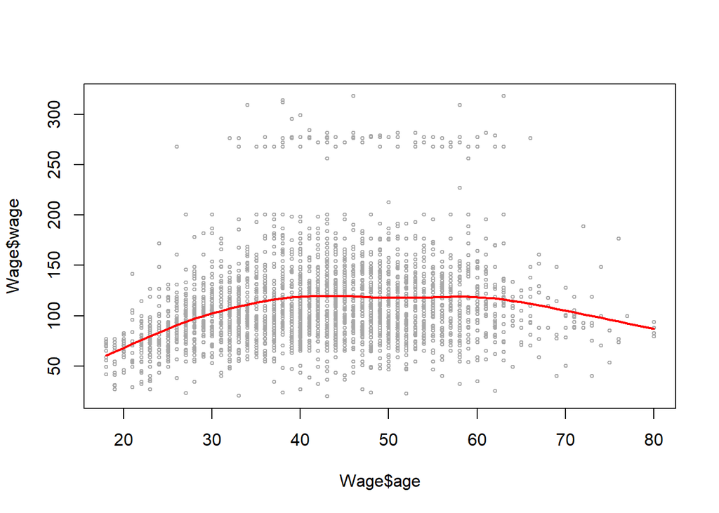

```r
plot(Wage$age, Wage$wage, cex = 0.5, col = "darkgrey")
lines(fit_smooth_cv, col = "red", lwd = 2)
```

### **Regresja lokalna**

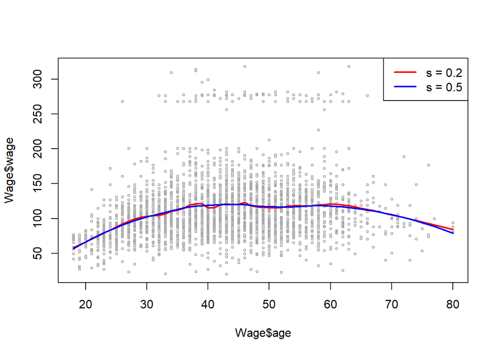

```r
spans <- c(0.2, 0.5)
clrs <- c("red", "blue")
plot(Wage$age, Wage$wage, cex = 0.5, col = "darkgrey")
for (i in 1:length(spans)) {
   fit_loess <- loess(wage ~ age, span = spans[i], data = Wage)
   pred_loess <- predict(fit_loess, data.frame(age = age_grid))
   lines(age_grid, pred_loess, col = clrs[i], lwd = 2)
}
legend("topright", legend = paste("s =", spans), col = clrs, lty = 1, lwd = 2)
```

To samo dla wielomianów stopnia 1.

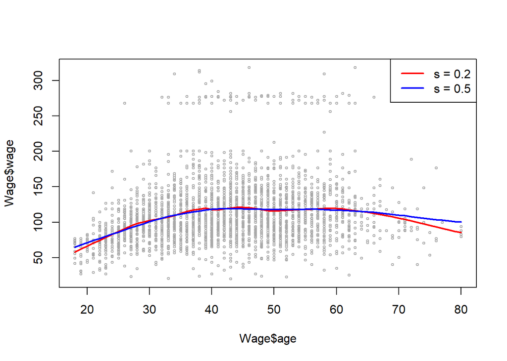

```r
spans <- c(0.2, 0.5)
clrs <- c("red", "blue")
plot(Wage$age, Wage$wage, cex = 0.5, col = "darkgrey")
for (i in 1:length(spans)) {
   fit_loess <- loess(wage ~ age, span = spans[i], degree = 1, data = Wage)
   pred_loess <- predict(fit_loess, data.frame(age = age_grid))
   lines(age_grid, pred_loess, col = clrs[i], lwd = 2)
}
legend("topright", legend = paste("s =", spans), col = clrs, lty = 1, lwd = 2)
```

### **Uogólnione modele addytywne (GAMs)**

GAM będący rozwinięciem modelu liniowego może być uczony metodą najmniejszych kwadratów przy pomocy funkcji `lm()`.

```r
fit_gam_ls <- lm(wage ~ ns(year, df = 4) + ns(age, df = 5) + education,
                 data = Wage)
fit_gam_ls
```

```
##
## Call:
## lm(formula = wage ~ ns(year, df = 4) + ns(age, df = 5) + education,
##     data = Wage)
##
## Coefficients:
##                 (Intercept)            ns(year, df = 4)1
##                      46.949                        8.625
##           ns(year, df = 4)2            ns(year, df = 4)3
##                       3.762                        8.127
##           ns(year, df = 4)4             ns(age, df = 5)1
##                       6.806                       45.170
##            ns(age, df = 5)2             ns(age, df = 5)3
##                      38.450                       34.239
##            ns(age, df = 5)4             ns(age, df = 5)5
##                      48.678                        6.557
##         education2. HS Grad     education3. Some College
##                      10.983                       23.473
##    education4. College Grad  education5. Advanced Degree
##                      38.314                       62.554
```

```r
summary(fit_gam_ls)
```

```
##
## Call:
## lm(formula = wage ~ ns(year, df = 4) + ns(age, df = 5) + education,
##     data = Wage)
##
## Residuals:
##      Min       1Q   Median       3Q      Max
## -120.513  -19.608   -3.583   14.112  214.535
##
## Coefficients:
##                             Estimate Std. Error t value Pr(>|t|)
## (Intercept)                   46.949      4.704   9.980  < 2e-16 ***
## ns(year, df = 4)1              8.625      3.466   2.488  0.01289 *
## ns(year, df = 4)2              3.762      2.959   1.271  0.20369
## ns(year, df = 4)3              8.127      4.211   1.930  0.05375 .
## ns(year, df = 4)4              6.806      2.397   2.840  0.00455 **
## ns(age, df = 5)1              45.170      4.193  10.771  < 2e-16 ***
## ns(age, df = 5)2              38.450      5.076   7.575 4.78e-14 ***
## ns(age, df = 5)3              34.239      4.383   7.813 7.69e-15 ***
## ns(age, df = 5)4              48.678     10.572   4.605 4.31e-06 ***
## ns(age, df = 5)5               6.557      8.367   0.784  0.43328
## education2. HS Grad           10.983      2.430   4.520 6.43e-06 ***
## education3. Some College      23.473      2.562   9.163  < 2e-16 ***
## education4. College Grad      38.314      2.547  15.042  < 2e-16 ***
## education5. Advanced Degree   62.554      2.761  22.654  < 2e-16 ***
## ---
## Signif. codes:  0 '***' 0.001 '**' 0.01 '*' 0.05 '.' 0.1 ' ' 1
##
## Residual standard error: 35.16 on 2986 degrees of freedom
## Multiple R-squared:  0.293,  Adjusted R-squared:  0.2899
## F-statistic:  95.2 on 13 and 2986 DF,  p-value: < 2.2e-16
```

Ogólniejsze GAM są uczone przy pomocy algorytmu dopasowania wstecznego w funkcji `gam()` z pakietu `gam`. Pakiet `gam` zawiera też funkcje implementujące modele nieparametryczne: `s()` reprezentującą wygładzające funkcje sklejane i `lo()` reprezentującą lokalną regresję.

```r
library(gam)
```

Dopasowanie modelu podobnego do poprzedniego, ale z użyciem wygładzających funkcji sklejanych.

```r
fit_gam_bf <- gam(wage ~ s(year, df = 4) + s(age, df = 5) + education, data = Wage)
summary(fit_gam_bf)
```

```
##
## Call: gam(formula = wage ~ s(year, df = 4) + s(age, df = 5) + education,
##     data = Wage)
## Deviance Residuals:
##     Min      1Q  Median      3Q     Max
## -119.43  -19.70   -3.33   14.17  213.48
##
## (Dispersion Parameter for gaussian family taken to be 1235.69)
##
##     Null Deviance: 5222086 on 2999 degrees of freedom
## Residual Deviance: 3689770 on 2986 degrees of freedom
## AIC: 29887.75
##
## Number of Local Scoring Iterations: NA
##
## Anova for Parametric Effects
##                   Df  Sum Sq Mean Sq F value    Pr(>F)
## s(year, df = 4)    1   27162   27162  21.981 2.877e-06 ***
## s(age, df = 5)     1  195338  195338 158.081 < 2.2e-16 ***
## education          4 1069726  267432 216.423 < 2.2e-16 ***
## Residuals       2986 3689770    1236
## ---
## Signif. codes:  0 '***' 0.001 '**' 0.01 '*' 0.05 '.' 0.1 ' ' 1
##
## Anova for Nonparametric Effects
##                 Npar Df Npar F  Pr(F)
## (Intercept)
## s(year, df = 4)       3  1.086 0.3537
## s(age, df = 5)        4 32.380 <2e-16 ***
## education
## ---
## Signif. codes:  0 '***' 0.001 '**' 0.01 '*' 0.05 '.' 0.1 ' ' 1
```

Wykres dla modelu dopasowanego funkcją `gam()`.

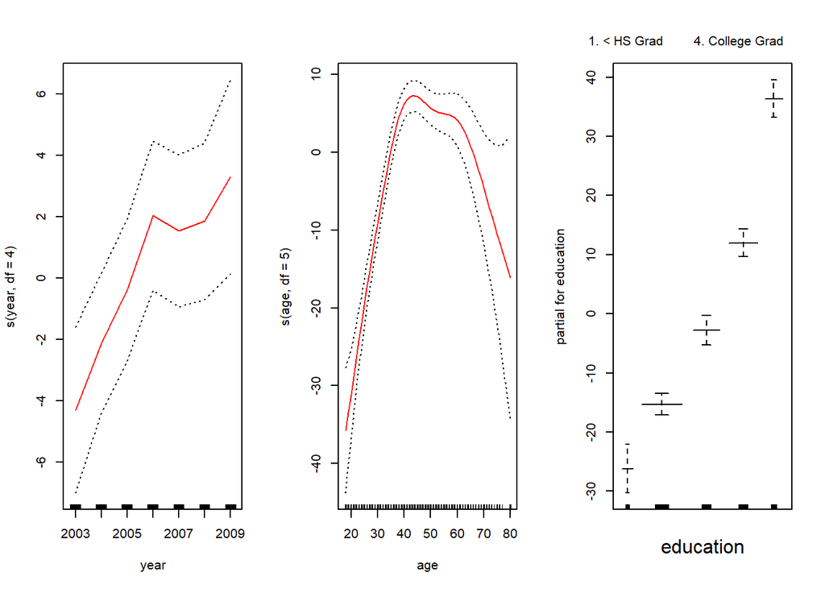

```r
par(mfrow = c(1, 3))
plot(fit_gam_bf, col = "red", se = TRUE)
```

Funkcja `plot.Gam()` działa też dla modeli metody najmniejszych kwadratów, ale wówczas trzeba się do niej odwołać jawnie.

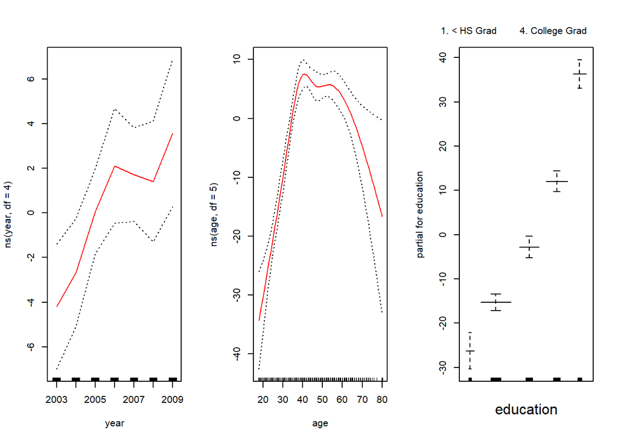

```r
par(mfrow = c(1, 3))
plot.Gam(fit_gam_ls, col = "red", se = TRUE)
```

Istnieje wersja funkcji `anova()` porównująca GAMs.

```r
fit_gam_1 <- gam(wage ~ s(age, df = 5) + education, data = Wage)
fit_gam_2 <- gam(wage ~ year + s(age, df = 5) + education, data = Wage)
anova(fit_gam_1, fit_gam_2, fit_gam_bf, test = "F")
```

```
## Analysis of Deviance Table
##
## Model 1: wage ~ s(age, df = 5) + education
## Model 2: wage ~ year + s(age, df = 5) + education
## Model 3: wage ~ s(year, df = 4) + s(age, df = 5) + education
##   Resid. Df Resid. Dev Df Deviance       F    Pr(>F)
## 1      2990    3711731
## 2      2989    3693842  1  17889.2 14.4771 0.0001447 ***
## 3      2986    3689770  3   4071.1  1.0982 0.3485661
## ---
## Signif. codes:  0 '***' 0.001 '**' 0.01 '*' 0.05 '.' 0.1 ' ' 1
```

Dopasowanie modelu wykorzystującego lokalną regresję.

```r
fit_gam_lo <- gam(wage ~ s(year, df = 4) + lo(age, span = 0.7) + education,
                  data = Wage)
summary(fit_gam_lo)
```

```
##
## Call: gam(formula = wage ~ s(year, df = 4) + lo(age, span = 0.7) +
##     education, data = Wage)
## Deviance Residuals:
##      Min       1Q   Median       3Q      Max
## -116.997  -19.319   -3.753   14.121  214.445
##
## (Dispersion Parameter for gaussian family taken to be 1243.534)
##
##     Null Deviance: 5222086 on 2999 degrees of freedom
## Residual Deviance: 3716672 on 2988.797 degrees of freedom
## AIC: 29903.95
##
## Number of Local Scoring Iterations: 1
##
## Anova for Parametric Effects
##                         Df  Sum Sq Mean Sq F value    Pr(>F)
## s(year, df = 4)        1.0   25188   25188  20.255 7.037e-06 ***
## lo(age, span = 0.7)    1.0  195537  195537 157.243 < 2.2e-16 ***
## education              4.0 1101825  275456 221.511 < 2.2e-16 ***
## Residuals           2988.8 3716672    1244
## ---
## Signif. codes:  0 '***' 0.001 '**' 0.01 '*' 0.05 '.' 0.1 ' ' 1
##
## Anova for Nonparametric Effects
##                     Npar Df Npar F  Pr(F)
## (Intercept)
## s(year, df = 4)         3.0  1.103 0.3464
## lo(age, span = 0.7)     1.2 88.835 <2e-16 ***
## education
## ---
## Signif. codes:  0 '***' 0.001 '**' 0.01 '*' 0.05 '.' 0.1 ' ' 1
```

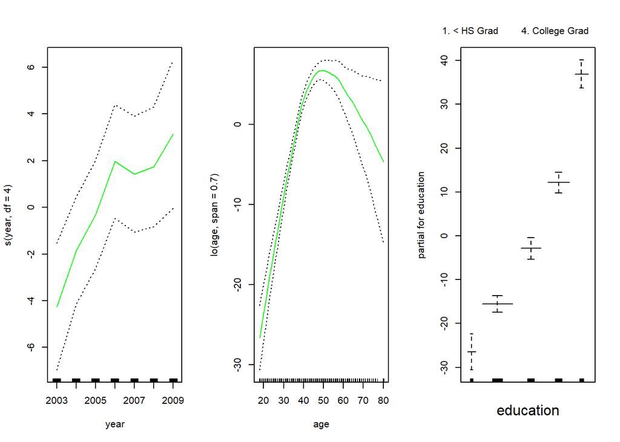

```r
par(mfrow = c(1, 3))
plot(fit_gam_lo, col = "green", se = TRUE)
```

### **GAM w GLM**

Regresja logistyczna wykorzystująca GAM

```r
fit_logistic_gam <- gam(I(wage > 250) ~ year + s(age, df = 5) + education,
                        family = binomial, data = Wage)
summary(fit_logistic_gam)
```

```
##
## Call: gam(formula = I(wage > 250) ~ year + s(age, df = 5) + education,
##     family = binomial, data = Wage)
## Deviance Residuals:
##      Min       1Q   Median       3Q      Max
## -0.58206 -0.26780 -0.12341 -0.08241  3.31242
##
## (Dispersion Parameter for binomial family taken to be 1)
##
##     Null Deviance: 730.5345 on 2999 degrees of freedom
## Residual Deviance: 602.4588 on 2989 degrees of freedom
## AIC: 624.4586
##
## Number of Local Scoring Iterations: NA
##
## Anova for Parametric Effects
##                  Df  Sum Sq Mean Sq F value  Pr(>F)
## year              1    0.48  0.4845  0.5995 0.43883
## s(age, df = 5)    1    3.83  3.8262  4.7345 0.02964 *
## education         4   65.81 16.4514 20.3569 < 2e-16 ***
## Residuals      2989 2415.55  0.8081
## ---
## Signif. codes:  0 '***' 0.001 '**' 0.01 '*' 0.05 '.' 0.1 ' ' 1
##
## Anova for Nonparametric Effects
##                Npar Df Npar Chisq  P(Chi)
## (Intercept)
## year
## s(age, df = 5)       4     10.364 0.03472 *
## education
## ---
## Signif. codes:  0 '***' 0.001 '**' 0.01 '*' 0.05 '.' 0.1 ' ' 1
```

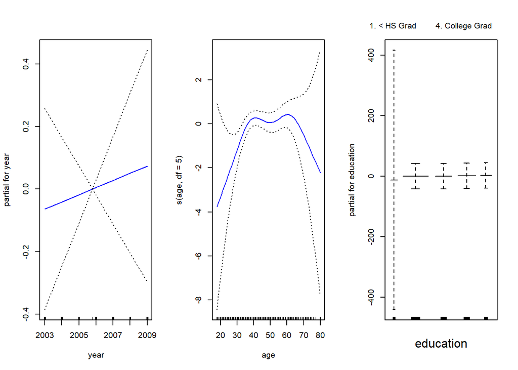

```r
par(mfrow = c(1, 3))
plot(fit_logistic_gam, col = "blue", se = TRUE)
```